# 市长电话分析

葛宇泽 19307130176

2021/11/3

### 1.读入市长电话训练集 trainset.csv 和测试集 testset.csv，统计训练集中各个政府单位接到的市民投诉量，并绘制柱状图（按照投诉量降序），简单陈述你观察到的现象

```r
#读入数据
setwd('F:/2021秋季/机器学习/HW5')
data_train = read.csv('train_set.csv',header=T,fileEncoding = "UTF-8")
data_test = read.csv('test_set.csv',header=T,fileEncoding = "UTF-8")

library(knitr)
library(ggplot2)
```

简要统计各政府单位收到的市民投诉量

```r
complaint = as.data.frame(table(as.vector(data_train$'单位名称')))
names(complaint) = c('name','num')
complaints = complaint
names(complaints) = c('政府单位','投诉数量')
kable(complaints)
```

| 政府单位 | 投诉数量 |
| --- | --- |
| 市房地集团 | 96 |
| 市公交集团 | 207 |
| 市供电公司 | 93 |
| 市供热公司 | 332 |
| 市燃气集团 | 285 |
| 市水务集团 | 557 |
| 市运输管理局 | 330 |

绘制柱状图

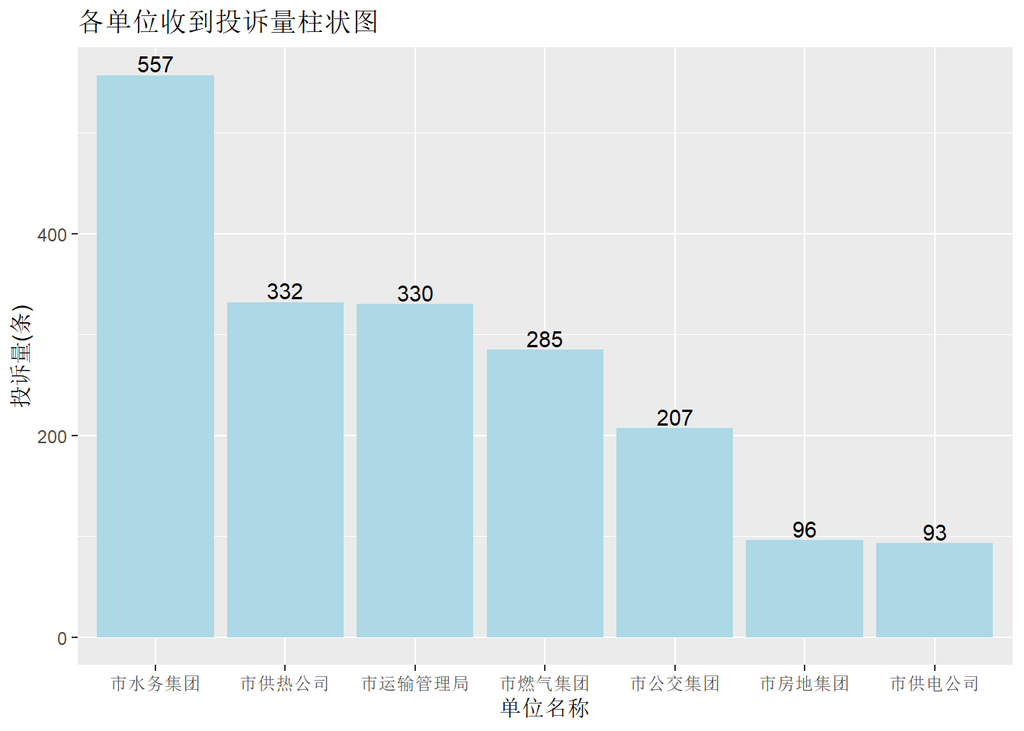

```r
ggplot(complaint,aes(x=reorder(name,-num),y=num))+
  geom_bar(stat = 'identity',fill='lightblue')+
  labs(x='单位名称',y='投诉量(条)',title='各单位收到投诉量柱状图')+
  geom_text(aes(label=num),vjust=-0.2)
```

1. 从图中可以看出，7个政府单位中，市水务集团收到的投诉最多，超过500条；市房地集团和市供电公司收到的投诉最少，均不超过100条。各单位收到投诉的数量在93到557之间。市供热公司、市运输管理局、市燃气集团收到投诉在300条左右，市公交集团收到投诉在200条左右。
2. 从收到投诉的数量来看，市水务集团的服务质量较差，需要改进；市房地产集团和市供电公司服务较好，民众对其相对满意。

### 2.统计每条投诉用词数并绘制分布直方图，简要分析你观察到的结果

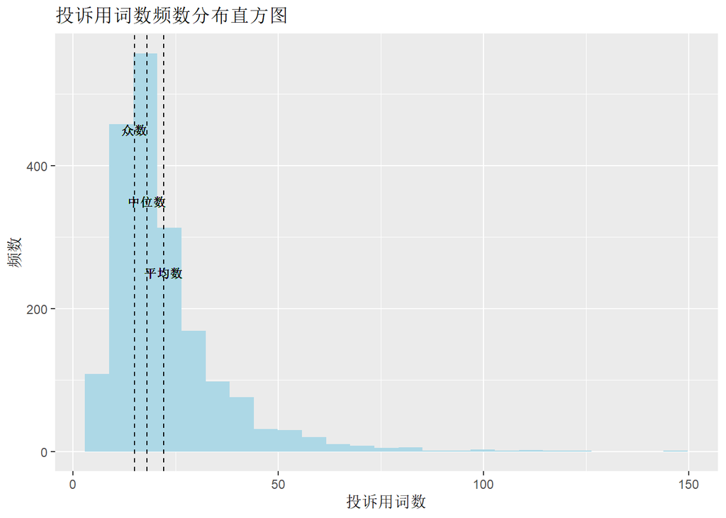

```r
#求出每条投诉的总词数
data_train$rowsum = rowSums(data_train[,-1])
#求出均值、中位数和众数
data_mean = mean(data_train$rowsum)
data_median = median(data_train$rowsum)
library(modeest)
data_mode = mfv(data_train$rowsum)
ggplot(data_train,aes(x=data_train$rowsum)) + geom_histogram(bins = 25,fill='light blue') +
  labs(x='投诉用词数',y='频数',title='投诉用词数频数分布直方图') +
  geom_vline(aes(xintercept=data_median), linetype="dashed") +
  geom_text(x=data_median,y=350,label='中位数',size=3) +
  geom_vline(aes(xintercept=data_mean),linetype='dashed') +
  geom_text(x=data_mean,y=250,label='平均数',size=3) +
  geom_vline(aes(xintercept=data_mode),linetype='dashed') +
  geom_text(x=data_mode,y=450,label='众数',size=3)
```

```r
summary(data_train$rowsum)
```

```
##    Min. 1st Qu.  Median    Mean 3rd Qu.    Max.
##    3.00   13.00   18.00   22.13   26.00  144.00
```

1.投诉用词最少为3，最多为144。观察直方图，投诉数据整体呈右偏分布，绝大部分投诉用词数低于50。大部分投诉用词较少，集中在10到30之间。

2.大部分投诉比较简单。词数较多的投诉可能是居民存在较大困难，应予以重视。

### 3.对每一个政府部门，统计每条投诉信息的词汇量，按照政府部门来绘制箱线图，尝试解读这个箱线图呈现的现象

按中位数由高到低绘制分组箱线图

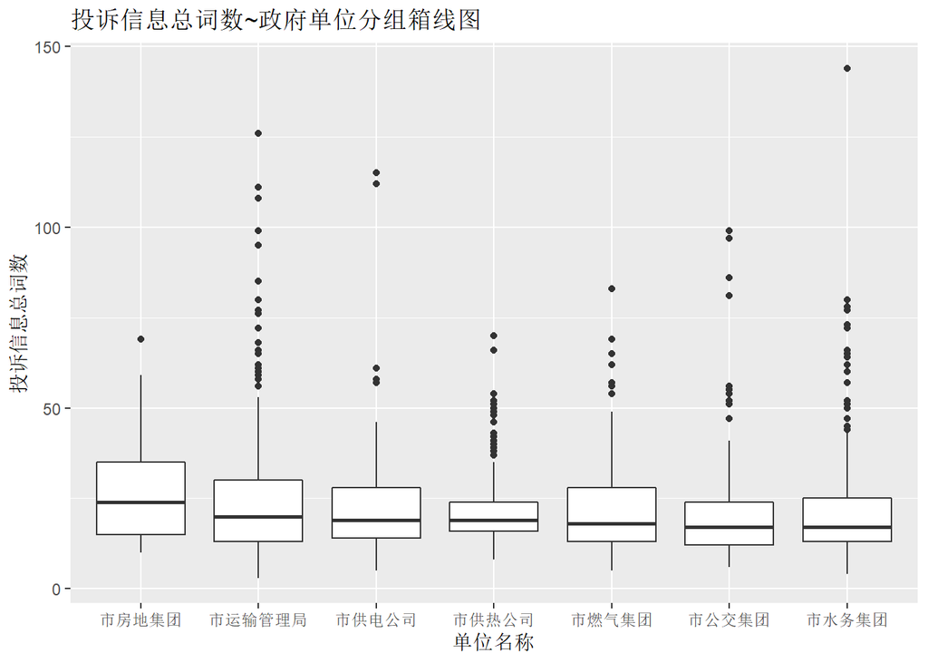

```r
ggplot(data_train,aes(x=reorder(data_train$单位名称,-data_train$rowsum,median),y=data_train$rowsum)) +
   geom_boxplot() + labs(x='单位名称',y ='投诉信息总词数',title='投诉信息总词数~政府单位分组箱线图' )
```

为了便于观察，将数据取对数后绘制分组箱线图

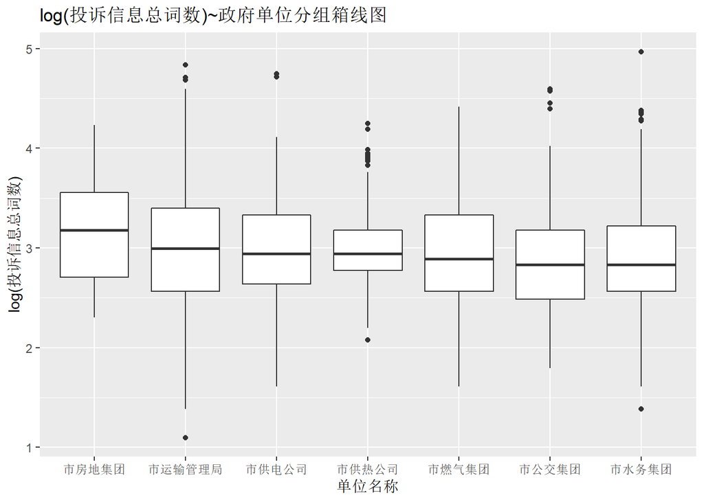

```r
ggplot(data_train,aes(x=reorder(data_train$单位名称,-data_train$rowsum,median),y=log(data_train$rowsum))) +
   geom_boxplot() + labs(x='单位名称',y ='log(投诉信息总词数)',title='log(投诉信息总词数)~政府单位分组箱线图' )
```

由图可知，大部分政府单位的投诉数量呈右偏分布，每个部门都大体符合上一问中直方图中的分布。

总体上，各个单位收到的每条投诉的投诉词数都不多，大部分不超过40。 各单位收到投诉词数相差不大，中位数都比较接近。 市房地集团、市运输管理局和市燃气集团的投诉词数分布相对分散，而市供热公司的投诉词数分布最为集中。

市房地集团收到的投诉词数相对较多，中位数最大，说明房地问题投诉描述相对复杂。市公交集团和市水务集团投诉次数与中位数相对较少，说明对这两类问题的投诉描述相对简单。

### 4.以训练集中的政府单位为因变量类别，电话文本为自变量，尝试用朴素贝叶斯方法对市政电话文本进行分类，并使用该模型对测试集电话文本进行预测，计算混淆矩阵，简要分析模型的效果

```r
library(e1071)
data_train$rowsum = NULL

trainset = data_train
testset = data_test
#词汇被使用记为1，未被使用记为0
trainset[,-1] = trainset[,-1]>0
testset[,-1] = testset[,-1]>0
#构建模型并进行预测，在训练集和测试集上查看效果
nB = naiveBayes(formula= 单位名称~.,data=trainset)
nB_train = predict(nB,trainset[,-1])
nB_pre = predict(nB,testset[,-1])
```

将模型运用在训练集上，查看效果

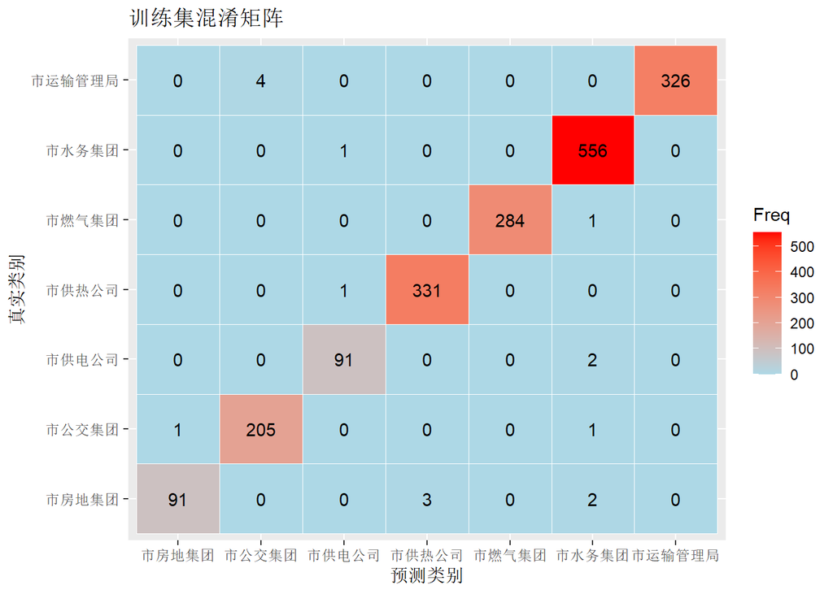

```r
nB_train_table = table(Tru=trainset$单位名称,Hyp=nB_train)
ggplot(as.data.frame(nB_train_table),aes(Hyp,Tru)) +
  geom_tile(aes(fill=Freq),color='white') +
  scale_fill_gradient(low='light blue',high='red') +
  geom_text(aes(label=Freq)) +
  labs(title='训练集混淆矩阵',x='预测类别',y='真实类别')
```

准确率为

```r
acc_train = sum(diag(nB_train_table))/sum(nB_train_table)
print(acc_train)
```

```
## [1] 0.9915789
```

将模型运用在测试集上，查看效果

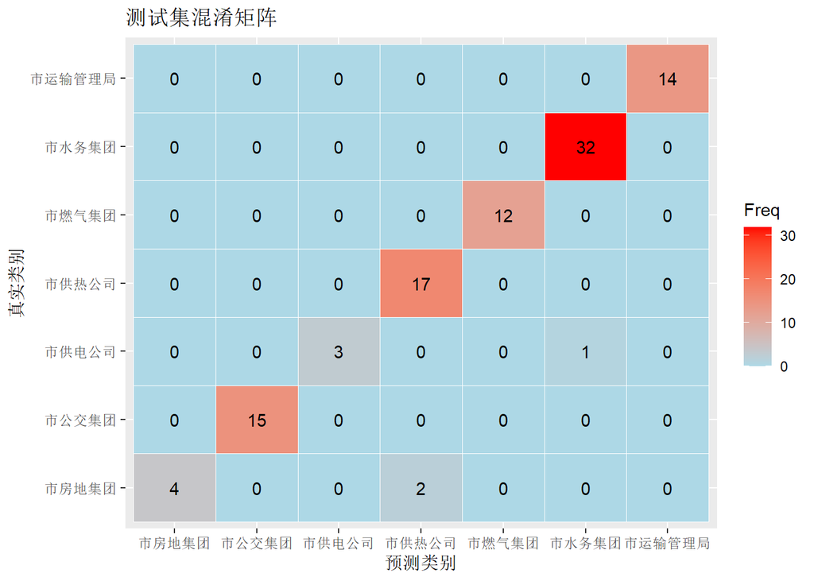

```r
nB_test_table = table(Tru=testset$单位名称,Hyp=nB_pre)
ggplot(as.data.frame(nB_test_table),aes(Hyp,Tru)) +
  geom_tile(aes(fill=Freq),color='white') +
  scale_fill_gradient(low='light blue',high='red') +
  geom_text(aes(label=Freq)) +
  labs(title='测试集混淆矩阵',x='预测类别',y='真实类别')
```

准确率为

```r
acc_test = sum(diag(nB_test_table))/sum(nB_test_table)
print(acc_test)
```

```
## [1] 0.97
```

就模型的预测结果来看，准确率达到97%，准确率较高，预测结果很好。在预测结果中，错误只发生在真实类别为市房地集团和市供电公司两类上，这可能是因为训练集中这两类投诉数据最少。

对训练集而言，模型的准确率达到99.16%，且测试集中的预测准确率也高达97%。这说明模型的拟合效果好，预测能力强，且有很好的泛化能力，没有出现过拟合现象。